# Image Processing Project Report

## Introduction

The JPEG format is a compressed binary format, well-suited for photos, for example. Based on what we've covered this semester, we don't yet have the necessary skills to manipulate such files in C++. Therefore, as in Lab 8, we will work with images in PBM (binary black and white images), PGM (grayscale images), and PPM (color images) formats. As we've seen, these formats allow us to encode images in human-readable text files, which are relatively easy to read and write in C++.

## Executive Summary

We validated the results visually (for example, by generating a QR code that redirects to "Salut Bob."). All components were successfully completed: one team member focused on the code implementation, while the other wrote the report. This project provided valuable hands-on experience in image processing and collaborative software development.

## Authors

- **Nguyen Duy Bao Nguyen**, duy-bao-nguyen.nguyen@universite-paris-saclay.fr, LDD EM – Primarily responsible for the **report**.
- **Jing Sichao**, sichao.jing@universite-paris-saclay.fr, LDD EM – Primarily responsible for writing the **code**.

## Work Summary

All parts of the project have been completed successfully:

- Part 1: Completed.
- Part 2: Completed.
- Part 3: Completed.
- Part 4: Completed.
- Part 5: Completed.
- Part 6: Completed.

## Demonstration

The following examples illustrate some of the results obtained for each part of the project, including code compilation and output images.

### Part 1

*Cells starting with `%%bash` are executed in a Bash shell (like a terminal).*

```python
%%bash --login
clang++ -g pbm-affiche.cpp -o pbm-affiche
```

```python
%%bash --login
./pbm-affiche
```

```
Affichage du smiley
```

```
      @ @ @ @
    @         @
  @             @
@     @     @     @
@
```

```
  @
@                 @
@     @     @     @
  @     @ @     @
    @         @
      @ @ @
```

```
 @
Fabrication du smiley inversé (vérifiez que le nouveau fichier a été créé dans le do
```

```
ssier pbm/smiley-inverse.pbm
```

```
Affichage du smiley inversé
```

```
@ @ @         @ @ @
@ @   @ @ @ @   @ @
@   @ @ @ @ @ @   @
  @ @   @ @   @ @
  @ @ @ @ @ @ @
```

```
@
  @ @ @ @ @ @ @ @
  @ @   @ @   @ @
@   @ @     @ @   @
@ @   @ @ @ @   @ @
@ @ @
```

```
   @ @ @
```

[figure not shown]

```python
# Display one of the generated images
from open_ppm import open_ppm
im = open_ppm("pbm/smiley-inverse.pbm")
im.resize((256*im.width // im.height, 256))
```

```python
%%bash --login
g++ pbm-tout-en-un.cpp -o pbm-tout-en-un
```

```python
%%bash --login
./pbm-tout-en-un
```

```
Vérifier que les images obtenues dans 'pbm/' sont semblables à celles fournies dans 'pbm/correctio
```

```
n/'
```

```
Vérifier que les images obtenues dans 'pbm/' sont semblables à celles fournies dans 'pbm/correctio
```

```
n/'
```

```
Affichage de l'image images/smiley.pbm
```

```
      @ @ @ @
    @         @
  @             @
@     @     @     @
@
```

```
  @
@                 @
@     @     @     @
  @     @ @     @
    @         @
      @ @ @
```

```
 @
Affichage de l'image pbm/smiley-inverse.pbm
@ @ @         @ @ @
@ @   @ @ @ @   @ @
@
```

```
@ @ @ @ @ @   @
  @ @   @ @   @ @
  @ @ @ @ @ @ @ @
  @ @ @ @ @ @ @ @
  @ @   @ @   @ @
```

```
@   @ @     @ @   @
@ @   @ @ @ @   @ @
@ @ @         @ @ @
```

### Results

[figure not shown]

```python
from open_ppm import open_ppm
im = open_ppm("pbm/code.pbm")
im.resize((160*im.width // im.height, 160))
```

[figure not shown]

```python
from open_ppm import open_ppm
im = open_ppm("pbm/code-inverse.pbm")
im.resize((160*im.width // im.height, 160))
```

We attempted to scan the QR code, and it redirected to **"Salut Bob."**

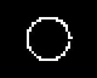

```python
from open_ppm import open_ppm
im1 = open_ppm("pbm/cercle.pbm")
im1.resize((160*im1.width // im1.height, 160))
```

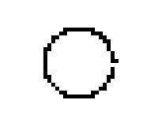

```python
from open_ppm import open_ppm
im = open_ppm("pbm/cercle-inverse.pbm")
im.resize((160*im.width // im.height, 160))
```

```python
from open_ppm import open_ppm
im = open_ppm("pbm/smiley.pbm")
im.resize((80*im.width // im.height, 80))
```

[output not shown]

```python
from open_ppm import open_ppm
im = open_ppm("pbm/smiley-inverse.pbm")
im.resize((80*im.width // im.height, 80))
```

[output not shown]

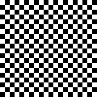

```python
from open_ppm import open_ppm
im = open_ppm("pbm/damier.pbm")
im.resize((160*im.width // im.height, 160))
```

[figure not shown]

```python
from open_ppm import open_ppm
im = open_ppm("pbm/damier-inverse.pbm")
im.resize((160*im.width // im.height, 160))
```

### Part 2

It's almost identical to Part 1; only minor modifications to the code were needed.

```python
%%bash --login
g++ pgm-tout-en-un.cpp -o pgm-tout-en-un
```

```python
%%bash --login
./pgm-tout-en-un
```

```
Vérifier que les images obtenues dans 'pgm/' sont semblables à celles fournies dans 'pgm/correctio
```

```
n/'
```

```
Vérifier que les images obtenues dans 'pgm/' sont semblables à celles fournies dans 'pgm/correctio
```

```
n/'
```

```python
from open_ppm import open_ppm
im = open_ppm("pgm/brain.pgm")
im.resize((100, 68))
```

[output not shown]

```python
from open_ppm import open_ppm
im = open_ppm("pgm/brain-inverse.pgm")
im.resize((100, 68))
```

[output not shown]

[figure not shown]

```python
from open_ppm import open_ppm
im = open_ppm("pgm/illusion.pgm")
im.resize((256*im.width // im.height, 256))
```

[figure not shown]

```python
from open_ppm import open_ppm
im = open_ppm("pgm/illusion-inverse.pgm")
im.resize((256*im.width // im.height, 256))
```

### Summary

- **readPGM**
- **writePGM**
- **invertPGM**

### Part 3

The horizontal intensity difference at pixel `(i,j)` is given by:

```
img[i-1][j-1] + 2*img[i][j-1] + img[i+1][j-1] - img[i-1][j+1] - 2*img[i][j+1] - img[i+1][j+1]
```

The vertical intensity difference is:

```
img[i-1][j-1] + 2*img[i-1][j] + img[i-1][j+1] - img[i+1][j-1] - 2*img[i+1][j] - img[i+1][j+1]
```

The total intensity is the norm of these horizontal and vertical differences.

```python
%%bash --login
g++ sobel-tout-en-un.cpp -o sobel-tout-en-un
```

```python
! ./sobel-tout-en-un
```

```
Vérifier que les images obtenues dans 'sobel/' sont semblables à celles fournies dans 'sobel/correction/'
```

*Note: There is no need to compute "intensiteH" and "intensiteV" separately. It is much more efficient to compute the combined intensity only once (instead of three times).*

### Renormalization

Renormalization is defined as: $$ ans_{i,j} = 255.0 \times \frac{img_{i,j} - \min}{\max - \min} $$ *(scaled proportionally to the intensity range)*

- First approach: if a pixel value exceeds 255, set it to 255 (clipping).
- Second approach: renormalize to preserve relative intensity differences (this yields lower contrast than the first approach).

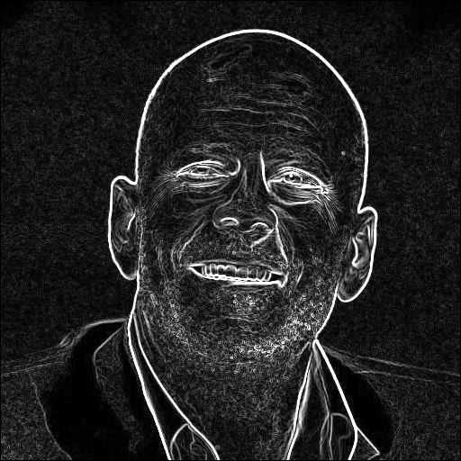

```python
from open_ppm import open_ppm
im = open_ppm("sobel/Willis.512.pgm")
im.resize((512*im.width // im.height, 512))
```

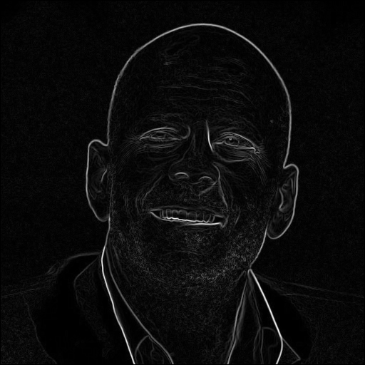

```python
from open_ppm import open_ppm
im = open_ppm("sobel/Willis_renormalise.512.pgm")
im.resize((512*im.width // im.height, 512))
```

### Thresholding: $(I = \sqrt{h^2 + v^2} > \text{Threshold})$?

```python
%%bash --login
g++ seuillage-tout-en-un.cpp -o seuillage-tout-en-un
```

```python
! ./seuillage-tout-en-un
```

```
Vérifier que les images obtenues dans 'seuillage/' sont semblables à celles fournies dans 'seuillage/correction/'
```

```
	Proposer des seuils pour Embryos.512.pgm et House.256.pgm
```

```
Vérifier que les images obtenues dans 'seuillage_double/' sont semblables à celles fournies dans 'seuillage_double/correction/'
```

```
	Proposer des seuils pour Embryos.512.pgm et House.256.pgm
```

```
Vérifier que les images obtenues dans 'seuillage_double/' sont semblables à celles fournies dans 'seuillage_double/correction/'
```

```
	Proposer des seuils pour Billes.256.pgm, Embryos.512.pgm et House.256.pgm
```

### Note

Use `!` to execute system commands from a notebook.

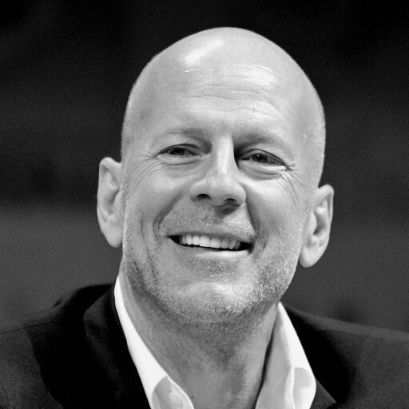

```python
from open_ppm import open_ppm
im = open_ppm("images/Willis.512.pgm")
im.resize((512*im.width // im.height, 512))
```

```python
from open_ppm import open_ppm
im = open_ppm("seuillage/Willis.512.pgm")
im.resize((512*im.width // im.height, 512))
```

[output not shown]

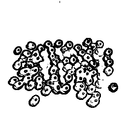

```python
from open_ppm import open_ppm
im = open_ppm("seuillage/Billes.256.pgm")
im.resize((256*im.width // im.height, 256))
```

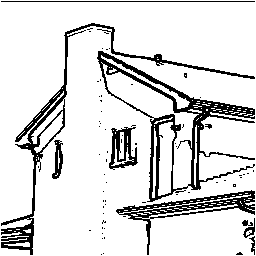

```python
from open_ppm import open_ppm
im = open_ppm("seuillage/House.256.pgm")
im.resize((256*im.width // im.height, 256))
```

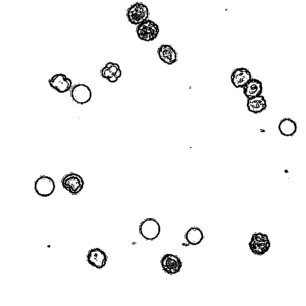

```python
from open_ppm import open_ppm
im = open_ppm("seuillage/Embryos.512.pgm")
im.resize((512*im.width // im.height, 512))
```

## Double Thresholding

- If (intensity > threshold) and (the pixel has a neighbor in `imgContour`), set the pixel to black.
- Otherwise, set it to white.
- Also: any pixel already in `imgContour` remains black.

## Our algorithm (pixel connectivity: 8 neighbors)

```
    for(int i = 0; i < height; i++)
        for(int j = 0; j < width; j++)
        {
            if (imgContour[i][j] == 0.0) // black pixel in contour image
            {
                ans[i][j] = 0.0;
                continue;
            }
            if(imgIntensite[i][j] > seuil)
            {
                // check neighbors
                bool Check = false;
                for(int di = -1; di <= 1; di++)
                {
                    if(Check) break; // optimization
                    for(int dj = -1; dj <= 1; dj++)
                    {
                        int ni = i + di, nj = j + dj;
                        if(ni >= 0 && ni < height && nj >= 0 && nj < width && !(di == 0 && dj == 0))
                        {
                            if(imgContour[ni][nj] == 0.0) // black pixel in contour image
                                Check = true;
                        }
                        if(Check) break; // optimization
                    }
                }
                ans[i][j] = (Check ? 0.0 : 255.0);
            }
            else
                ans[i][j] = 255.0; // White pixel
        }
```

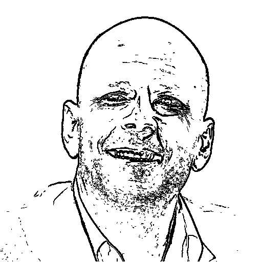

```python
from open_ppm import open_ppm
im = open_ppm("seuillage_double/Willis.512.pgm")
im.resize((512*im.width // im.height, 512))
```

## Iterative Optimization

Using the current edges (`imgContour`) as a starting point, find weak neighbors (intensity > `lowThreshold`) of these edges, mark them as edges, and form a new `imgContour`. Repeat this process a fixed number of times.

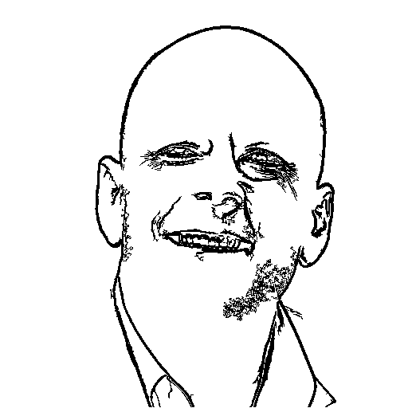

```python
from open_ppm import open_ppm
im = open_ppm("seuillage_double/iteratif_Willis.512.pgm")
im.resize((512*im.width // im.height, 512))
```

## Smoothing

Replace each pixel’s value with the average of itself and its 8 neighbors.

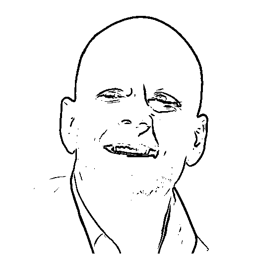

```python
from open_ppm import open_ppm
im = open_ppm("seuillage/Willis_lissage.512.pgm")
im.resize((512*im.width // im.height, 512))
```

## Improvement - BFS

Build a queue. Start by enqueuing all pixels above `strongThreshold`. For each pixel in the queue, check its neighbors that are above `weakThreshold` to find connected edge points.

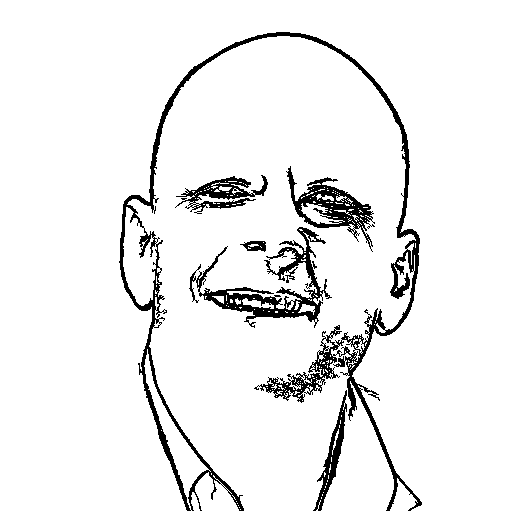

```python
from open_ppm import open_ppm
im = open_ppm("seuillage_double/iteratif_Willis_Amelioration.512.pgm")
im.resize((512*im.width // im.height, 512))
```

### Part 4

**Note:** We use `#ifndef ... #define ... #endif` include guards so that each header is compiled only once, avoiding redefinition errors.

```python
%%bash --login
clang++ -g pgm.cpp pgm-test.cpp -o pgm.test
```

```python
%%bash --login
make pgm-test
```

```
make: 'pgm-test' is up to date.
```

```python
%%bash --login
./pgm-test
```

```
Tests des fonctions lirePGM et ecrirePGM
```

```
Tests de la fonction inverseePGM
```

```python
from open_ppm import open_ppm
im = open_ppm("pgm/brain.pgm")
im.resize((100, 68))
```

[output not shown]

```python
from open_ppm import open_ppm
im = open_ppm("pgm/brain-inverse.pgm")
im.resize((100, 68))
```

[output not shown]

[figure not shown]

```python
from open_ppm import open_ppm
im = open_ppm("pgm/illusion.pgm")
im.resize((256*im.width // im.height, 256))
```

[figure not shown]

```python
from open_ppm import open_ppm
im = open_ppm("pgm/illusion-inverse.pgm")
im.resize((256*im.width // im.height, 256))
```

### Sobel

```python
%%bash --login
make sobel-test
```

```
make: 'sobel-test' is up to date.
```

```python
! ./sobel-test
```

```
Vérifier que les images obtenues dans 'sobel/' sont semblables à celles fournies dans 'sobel/correction/'
```

### Thresholding

```python
%%bash --login
make seuillage-test
```

```
make: 'seuillage-test' is up to date.
```

```python
! ./seuillage-test
```

```
Tests de renormalisation...
Tests de seuillage...
Vérifier que les images obtenues dans 'seuillage/' sont semblables à celles fournies dans 'seuillage/correction/'
```

```
	Proposer des seuils pour Embryos.512.pgm et House.256.pgm
```

```
Tests de double seuillage...
Vérifier que les images obtenues dans 'seuillage_double/' sont semblables à celles fournies dans 'seuillage_double/correction/'
```

```
	Proposer des seuils pour Embryos.512.pgm et House.256.pgm
```

```
Tests de double seuillage itératif...
Vérifier que les images obtenues dans 'seuillage_double/' sont semblables à celles fournies dans 'seuillage_double/correction/'
```

```
	Proposer des seuils pour Billes.256.pgm, Embryos.512.pgm et House.256.pgm
```

```
Tous les tests sont passés !
```

```python
from open_ppm import open_ppm
im = open_ppm("seuillage/Willis.512.pgm")
im.resize((512*im.width // im.height, 512))
```

[output not shown]

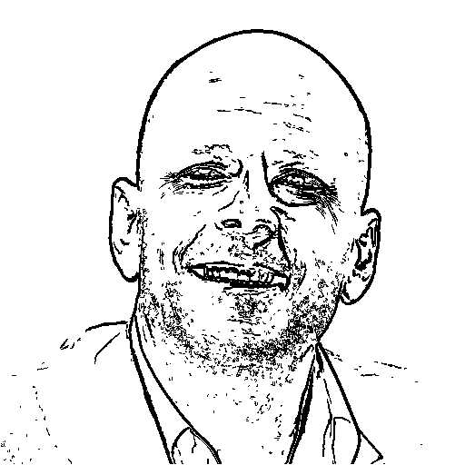

```python
from open_ppm import open_ppm
im = open_ppm("seuillage_double/Willis.512.pgm")
im.resize((512*im.width // im.height, 512))
```

### TIN

```python
%%bash --login
make TIN
```

```
make: 'TIN' is up to date.
```

```python
%%bash --login
./TIN -e images/Willis.512.pgm seuillage/Willis.512.pgm
```

```python
from open_ppm import open_ppm
im = open_ppm("seuillage/Willis.512.pgm")
im.resize((512*im.width // im.height, 512))
```

[output not shown]

### Part 5

**Note:** Use `make images` to convert `*.jpg` files to `*.ppm` and `*.pgm`.

```python
%%bash --login
make images
```

```
make: Nothing to be done for 'images'.
```

```python
%%bash --login
make ppm-test
```

```
make: 'ppm-test' is up to date.
```

```python
! ./ppm-test
```

```
Tests des fonctions lirePPM et ecrirePPM
Vérifier que les images obtenues dans 'ppm/' sont identiques aux images d'origine dans 'images/'
```

```python
%%bash --login
make gris-couleurs-test
```

```
make: 'gris-couleurs-test' is up to date.
```

```python
! ./gris-couleurs-test
```

```
Tests de la fonction couleurAuGris
Vérifier les images obtenues dans 'gris-couleurs/'
```

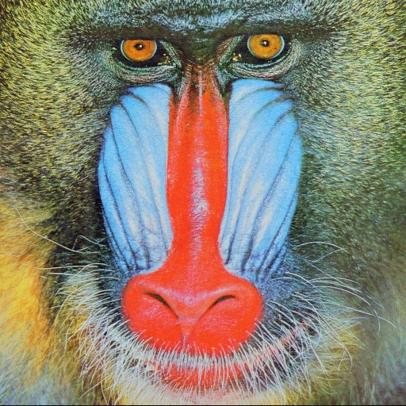

```python
from open_ppm import open_ppm
im = open_ppm("ppm/Baboon.512.ppm")
im.resize((512*im.width // im.height, 512))
```

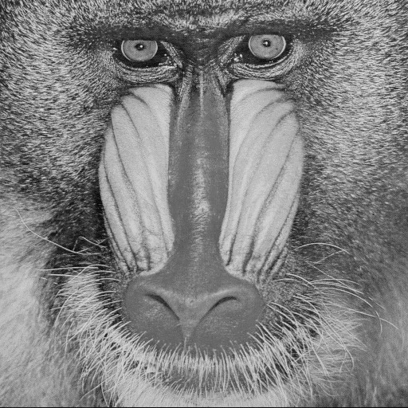

```python
from open_ppm import open_ppm
im = open_ppm("gris-couleurs/Baboon.512.pgm")
im.resize((512*im.width // im.height, 512))
```

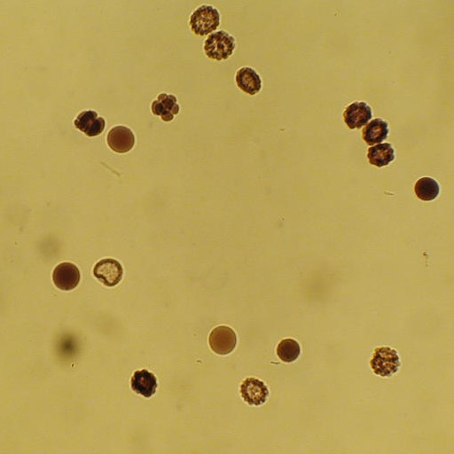

```python
from open_ppm import open_ppm
im = open_ppm("ppm/Embryos.512.ppm")
im.resize((512*im.width // im.height, 512))
```

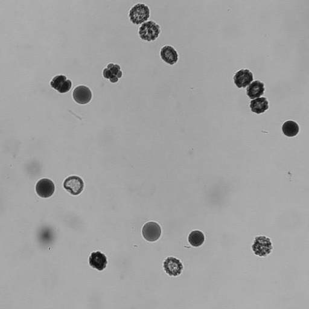

```python
from open_ppm import open_ppm
im = open_ppm("gris-couleurs/Embryos.512.pgm")
im.resize((512*im.width // im.height, 512))
```

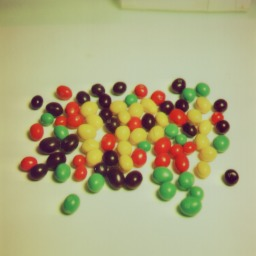

```python
from open_ppm import open_ppm
im = open_ppm("ppm/Billes.256.ppm")
im.resize((256*im.width // im.height, 256))
```

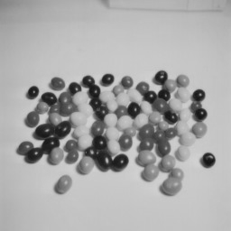

```python
from open_ppm import open_ppm
im = open_ppm("gris-couleurs/Billes.256.pgm")
im.resize((256*im.width // im.height, 256))
```

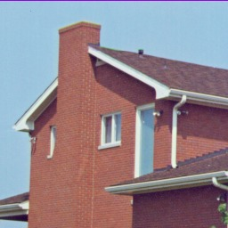

```python
from open_ppm import open_ppm
im = open_ppm("ppm/House.256.ppm")
im.resize((256*im.width // im.height, 256))
```

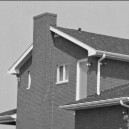

```python
from open_ppm import open_ppm
im = open_ppm("gris-couleurs/House.256.pgm")
im.resize((256*im.width // im.height, 256))
```